# **Customer Experience Survey Report**

IT Strategy and Planning Reporting Team

August 8, 2018

# **Overview & Summary**

The purpose of this project was to have a stronger understanding of user preference when submitting a ticket. A *Qualtrics* survey was created to receive user feedback based on their experiences with the IT ticket submission process. In total there were **110 participants**, broken up to **37 students** , **37 faculty members** and **36 administrators**.

## **Most Common Users**

There are significantly more **administrators**, **faculty and staff** that submit tickets compared to **students**. Improvements to the IT ticket submission process whould be geared toward the faculty and administrators as opposed to students.

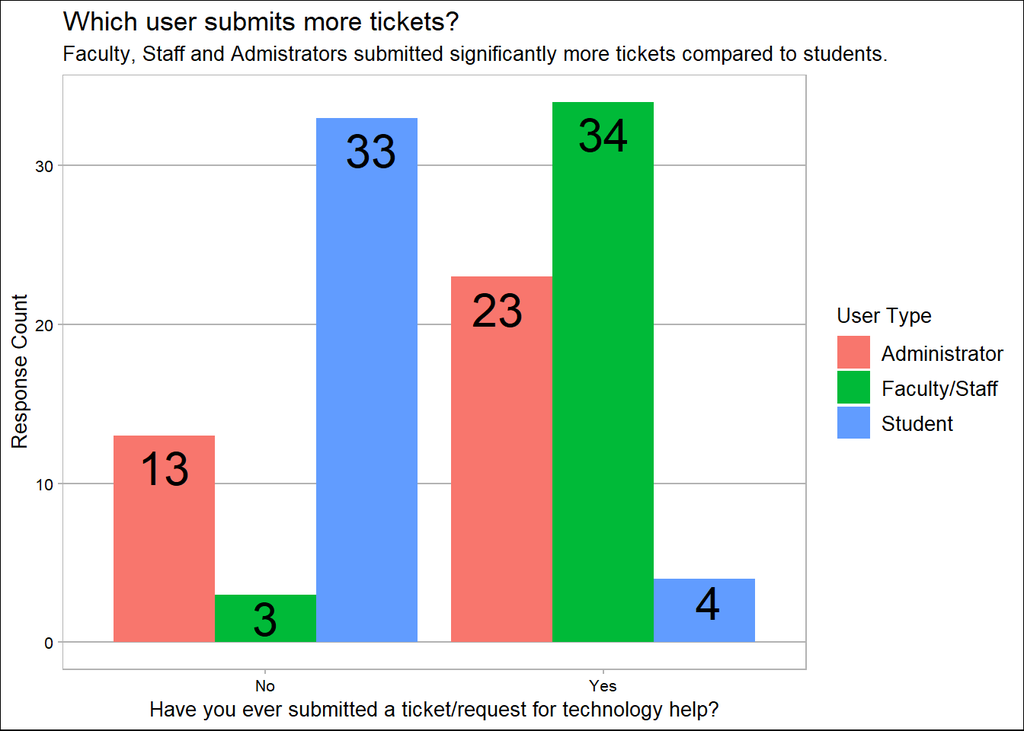

## **Ticket Response Time**

Of the 58 surveyed users who submitted an IT ticket request and received a follow up, 36 of the users were contacted within one day or less. While this accounted for 62.1% of the users, the desire is to increase the response rate. It is true that IT issues can require much time befoe resolution, the **act of contacting the ticket requestor can be quick and immedeate**. One possible result of increased response times would be less frustration and higher user satisfaction.

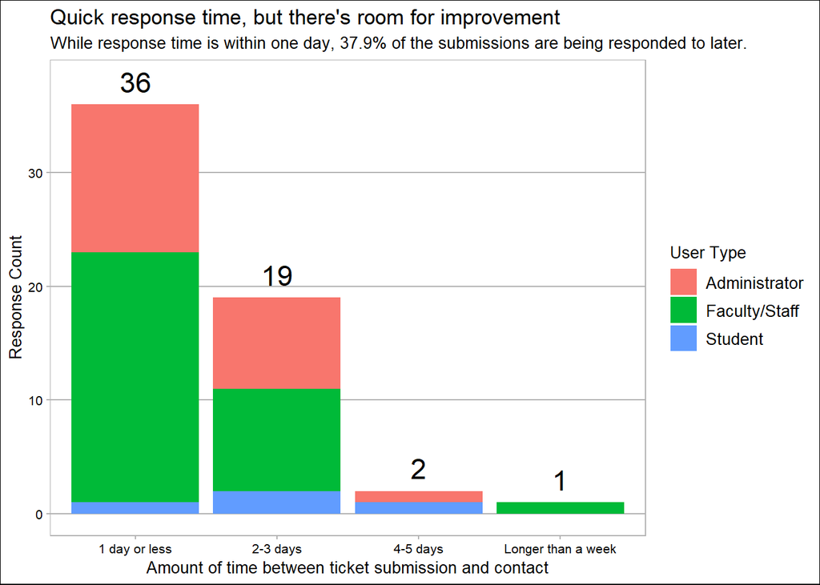

## **Popular Services and Satisfaction**

Users were asked to select all of the services that they had used in the past. The services consisted of Phone, Email, Walk In, Web Form, Live Chat, Self Help Articles as well as an option for None of the Above. Of the **110 users surveyed**, there were **72 users** who received help via **Phone**, and **54 users** who received hlep via **Email**. After using the service, 76 users responded saying that their issue was resolved via their selected service, while 13 users responded negatively, witht their service left unsolved. This gives a **success rate of 85.4%**.

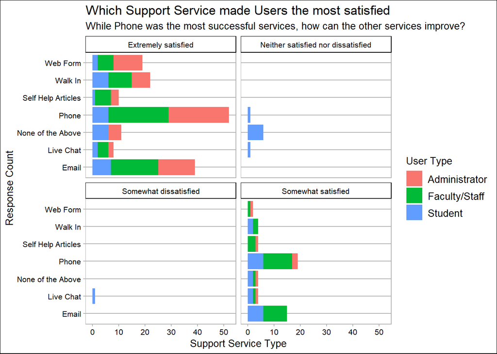

## **User Service Preferences**

Users were asked to rank six different IT service options according the service they would most likely use first. In the heat map, the darker the shade of blue on the gradient meant more votes received in that category. As we can see, Phone service was ranked as the number one preferred option. The average preferences were:

**1. Phone**

**2. Email**

**3. Walk In**

**4. Web Form**

**5. Self Help Articles**

**6. Live Chat**

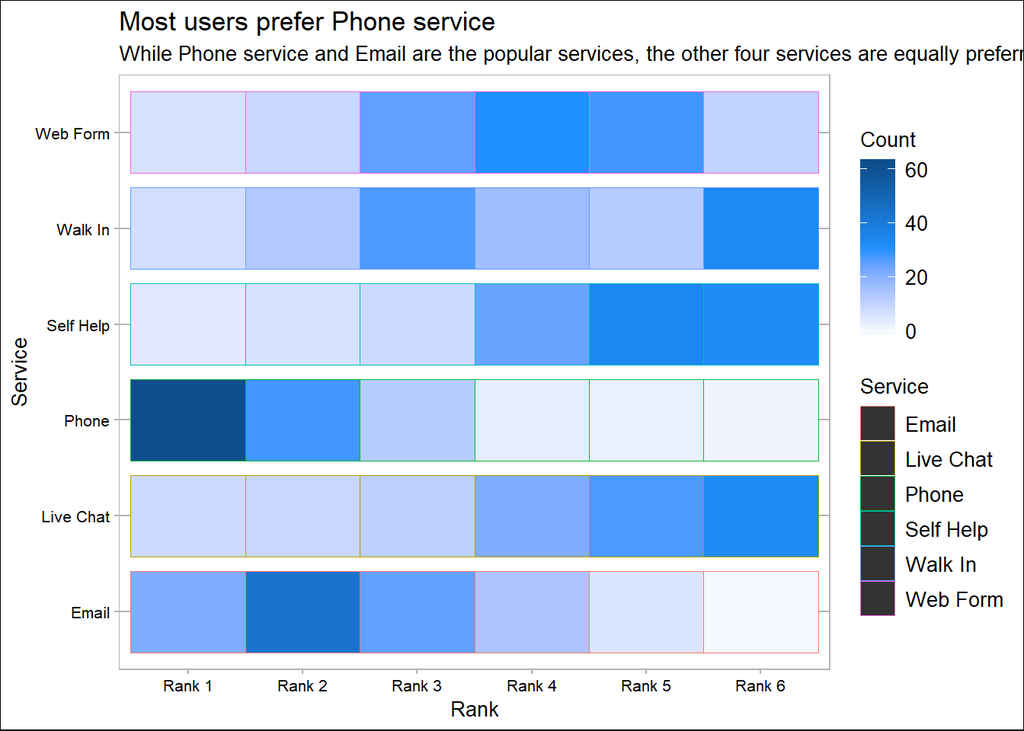

After receiving the initial question, users were shown the **average resolution times for each service**.

- Web Form: 34.2 hours or 4 days
- Email: 34.2 hours or 4 days
- Walk In: 30.2 hours or 3 days
- Phone: 18.11 hours or 2 days
- Live Chat: 11.39 hours or 1.5 days
- Self Help Articles: At your convenience

After learning of the average resolution times, users were then asked the same question as to their preference of service. Please note that while **Live Chat** was ranked last, it is the service with the quickest average resolution time.

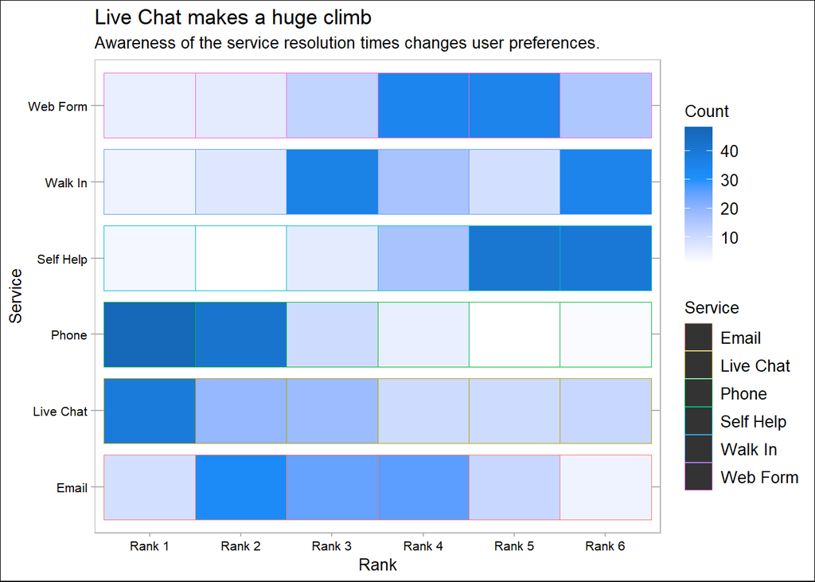

The new user ranking for preferred service now has **Live Chat** ranked at second.

**1. Phone**

**2. Live Chat** (Moved up from 6th to 2nd)

**3. Email**

**4. Walk In**

**5. Web Form**

**6. Self Help Articles**

If there was more user awareness, would IT Live Chat become a more prominent service option for users with IT ticket issues?